# Exam exercise for Module 1: Wind speed distributions

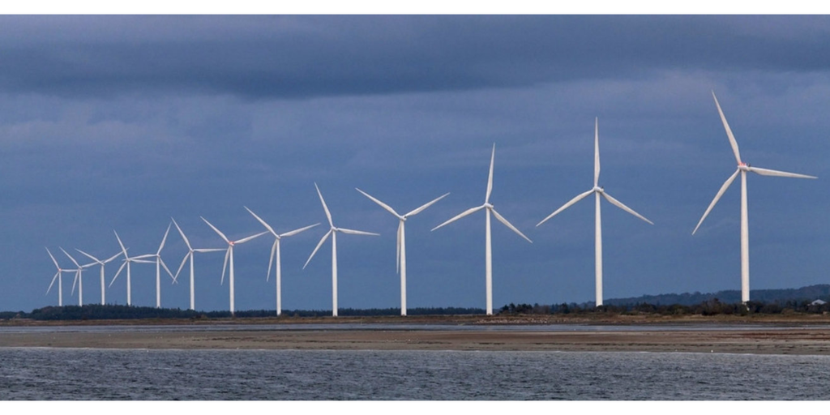

In this workshop we consider a continuous probability distribution called the Weibull distribution. Among other things, it is used to model wind speed distributions.

We recommend that you answer the exercises using Rmarkdown (you can simply use the exam Rmarkdown file as a starting point).

# Part I: The Weibull distribution

The Weibull distribution depends on two parameters $k>0$ and $\lambda>0$. If $X$ follows a Weibull distribution with parameters $k$ and $\lambda$, we write $X\sim \texttt{weibull}(k,\lambda)$. In this case, $X$ has the probability density function
$$f(x)=\begin{cases}\frac{k}{\lambda}\left(
\frac{x}{\lambda}\right)^{k-1}e^{-(x/\lambda)^k},& x \geq 0,\\
0,&x< 0,\end{cases}$$
and the distribution function
$$F(x)=\begin{cases}1 - e^{-(x/\lambda)^k},& x \geq 0,\\
0,&x < 0.\end{cases}$$

The parameter $k$ is called the shape parameter, since it determines the shape of the distribution, while $\lambda$ is called the scale parameter, because it works by scaling the $x$-axis.

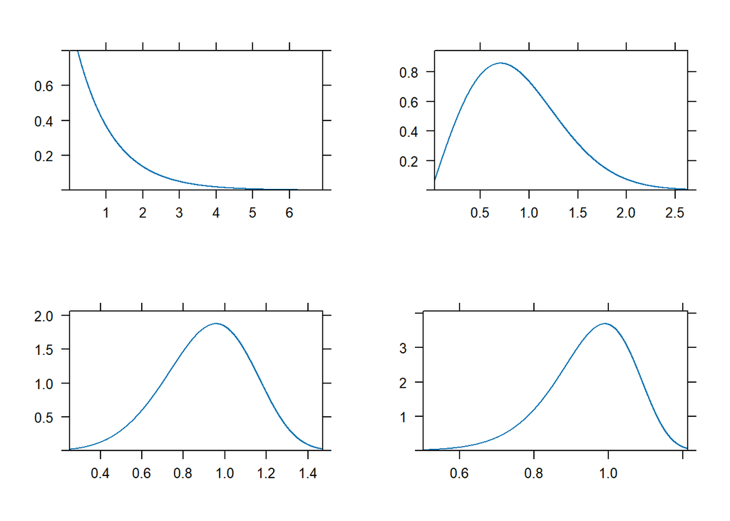

```r
lambda <- 1
k <- 1
w1 <- plotDist("weibull", params = list(shape = k, scale = lambda))
k <- 2
w2 <- plotDist("weibull", params = list(shape = k, scale = lambda))
k <-5
w3 <- plotDist("weibull", params = list(shape = k, scale = lambda))
k <- 10
w4 <- plotDist("weibull", params = list(shape = k, scale = lambda))
grid.arrange(w1, w2, w3, w4, ncol = 2)
```

We then the run the same changes but for lambda and see how the scale changes:

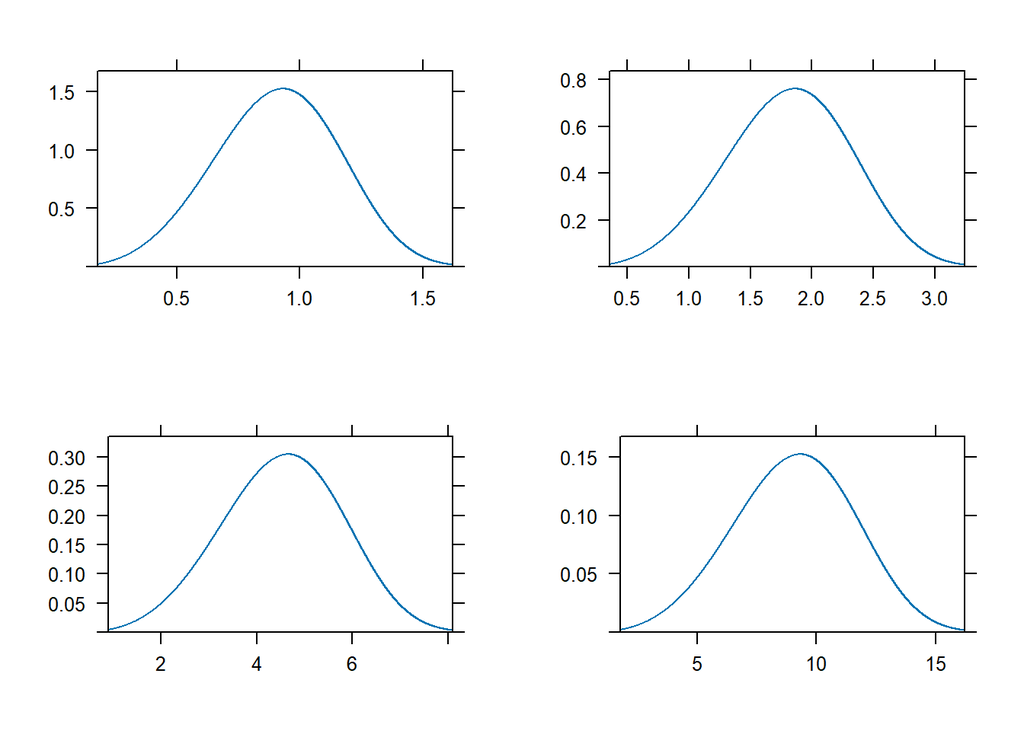

```r
lambda <- 1
k <- 4
w1 <- plotDist("weibull", params = list(shape = k, scale = lambda))
lambda <- 2
w2 <- plotDist("weibull", params = list(shape = k, scale = lambda))
lambda <-5
w3 <- plotDist("weibull", params = list(shape = k, scale = lambda))
lambda <- 10
w4 <- plotDist("weibull", params = list(shape = k, scale = lambda))
grid.arrange(w1, w2, w3, w4, ncol = 2)
```

Here we see that lambda defines how “sharp” or “pointy” the function is, larger lambda means longer tails or larger variance. It also seems that the center is around lambdas value.

2. Assume that $x \geq 0$. Show that the distribution function $F(x)$ satisfies
   $$\ln(-\ln(1-F(x)))=-k\ln(\lambda)
   + k\ln(x).$$

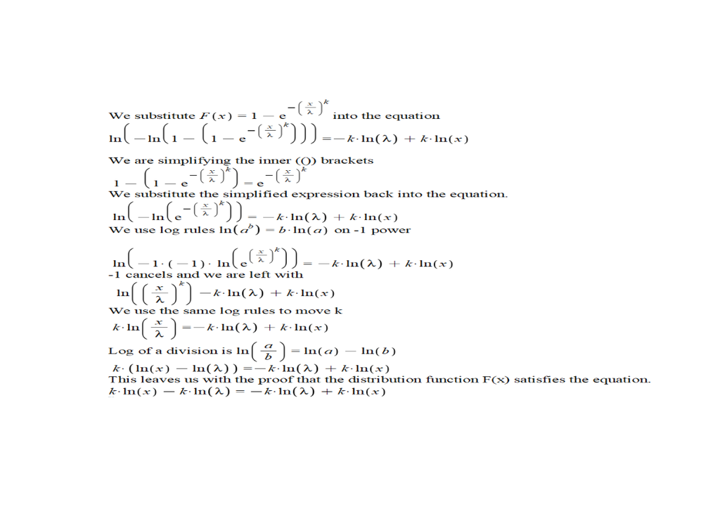

```r
library("png")
pp <- readPNG("1.2.png")
plot.new()
rasterImage(pp,0,0,1,1)
```

# Part II: Wind speed measurements

In this part we consider a data set containing wind speed measurements from a Danish weather station located at Sjælsmark. The data set contains the wind speed measured at 12 noon every day of January in the years 2001-2019. We first load the data set:

```r
speed<-read.delim("https://asta.math.aau.dk/datasets?file=windSpeed.txt",header=FALSE)[,1]
```

1. Draw a histogram of the wind speed observations by editing the R chunk below. Explain how a histogram is constructed. Do you think the observations come from a normal distribution?

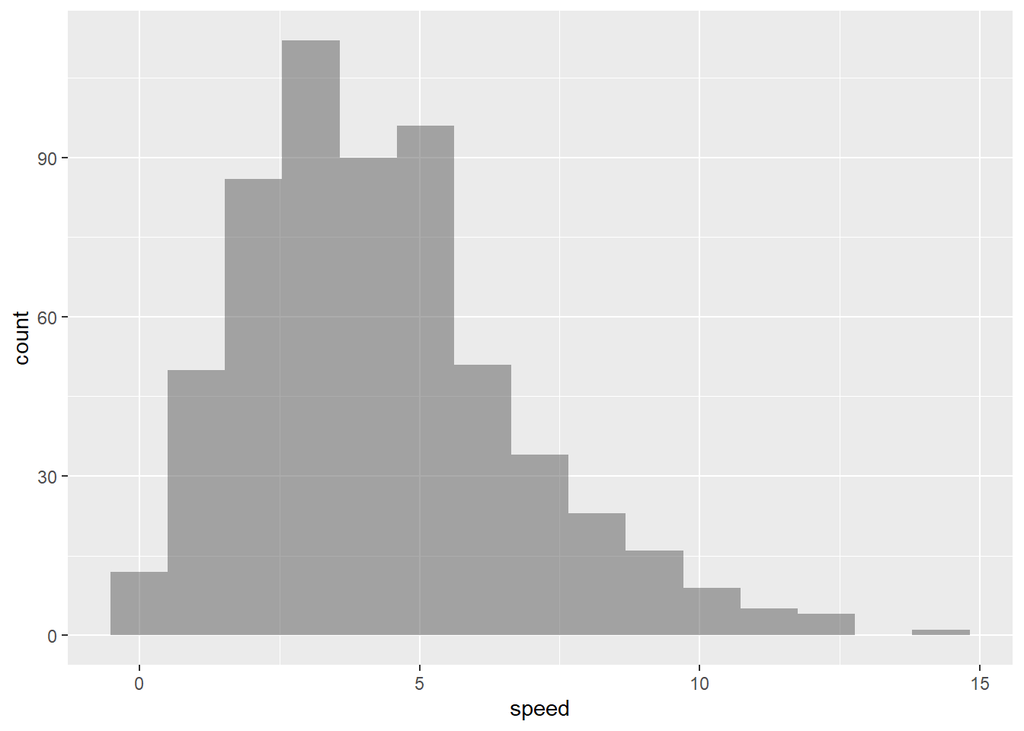

```r
#hist(speed)
gf_histogram(~speed,bins=15)
```

This is clearly bot gaussian (normal), it is skewed, and looks a lot like Weibull dist. with k approx. around 2, see figures from task 1.

In the following we will convince ourselves that the data actually comes from a Weibull distribution. We order the $n=589$ observations from smallest to largest
$$x_{(1)}\leq x_{(2)}\leq \dotsm \leq
x_{(n)}.$$

2. Argue that $F(x_{(i)})\approx \tfrac{i}{n}$ for $i=1,\ldots,n$. (Hint: How many observations are less than or equal to $x_{(i)}$?)

The distribution funciton F(x), gives the probability of a value being in the range from 0 to x. Thus if we where to compute F(10) it would return the probability of getting a value from 0 to 10. Much in the same way, if we say i =250, and compute 250/589 = 0.424 this means, that the probability of an output being in the span from 0 to the x value at index 250 would be 0.424. In other words, we know that all value below the i’th index must be smaller than the value at the i’th index and as such i/n approximates F(x).

3. Using Exercise 2 in Part I, argue that if the observations come from a $\texttt{weibull}(k,\lambda)$ distribution, then
   $$\ln(-\ln(1-\tfrac{i}{n}))\approx -k\ln(\lambda) +
   k\ln(x_{(i)}).$$

We earlier showed that the equation is true, And we have now reasoned that i/n approximates F(x), thus if x(i) approximates x in a discrete case, then we conclude that the discrete equation must be approximately true as well.

The code below computes a vector containing the values $v_i=\ln(-\ln(1-\tfrac{i}{n}))$ and a vector containing the values $u_i = \ln(x_{(i)}).$

Another reasonanle explanation would be that i/n approximates F(x), and F(x) is an exponential function, thus -ln(1-F(x)) would be expected to behave linearly. we then take ln again such that we have ln(-ln(1-F(x))) and thus should behave like a log function. On the other side we have a linear function x, and we take ln(x), resulting in a log behaviour, and plotting a log log function will yield a linear graph.

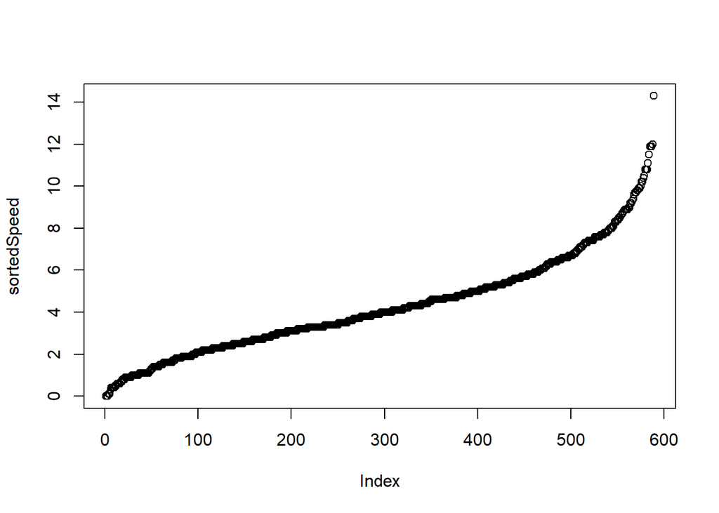

```r
n<-length(speed)
sortedSpeed<-sort(speed)
u<-log(sortedSpeed)
CDF<-(1:n)/n
v<-log(-log(1-CDF))
#gf_point(v ~ u)
plt1 <- plot(sortedSpeed)
```

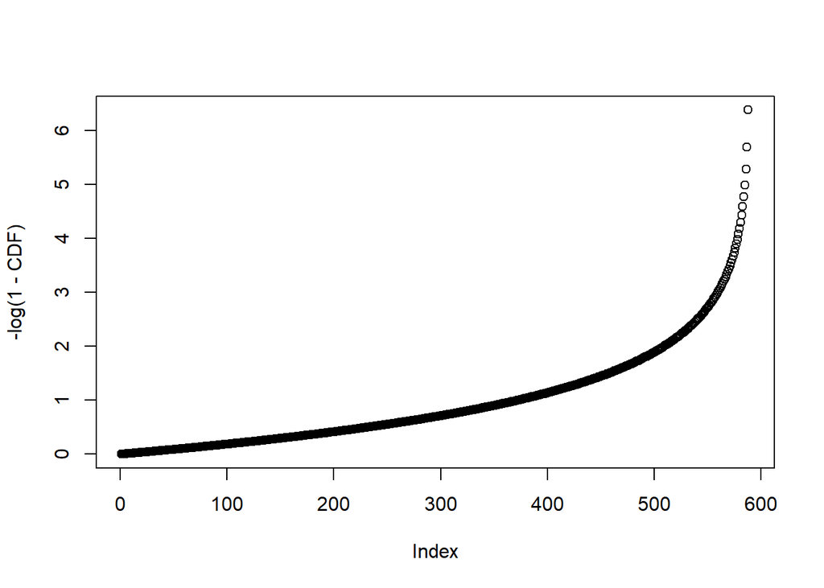

```r
plt2 <- plot(-log(1-CDF))
```

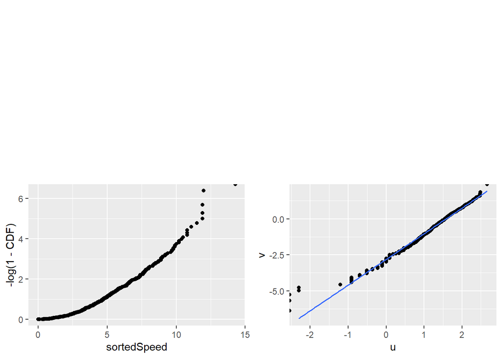

```r
plt3 <- gf_point(-log(1-CDF) ~ sortedSpeed)
plt4 <- gf_point(v~u)%>%gf_lm()
grid.arrange(plt1, plt2, plt3, plt4, ncol = 2)
```

```r
#gf_point(...~...) %>%gf_lm()
```

4. Argue that the points $(u_i,v_i)$ should lie approximately on a straight line if the observations come from a $\texttt{weibull}(k,\lambda)$ distribution. Edit the code above to check that this is the case.
5. The intercept and slope of the line can be found to be $-2.82$ and $1.78$, respectively. Use this to give estimates of the parameters $k$ and $\lambda$ of the model. Insert these values in the code below to plot the histogram together with the approximate density (`shape` is $k$ and `scale` is $\lambda$).

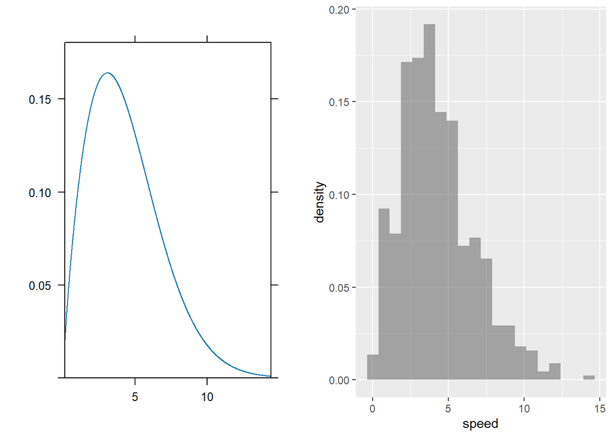

```r
plt5 <- plotDist("weibull", params = list(shape = 1.78, scale = 4.876))
plt6 <- gf_dhistogram( ~ speed, bins = 20)
grid.arrange(plt5, plt6, ncol = 2)
```

```r
 #%>%
#gf_dist("weibull", shape = ..., scale = ..., col = "red")
```

We can see the QQ plot as a xy plot, where x is -k ln(lambda)+k ln(xi) and y is ln(-ln(1-i/n)). We know that it forms a straight line, and as such, we can see the right side as the “input” and the left side as the “output”. A linaer fit follows the form a*x+b where b is the value of intersection with the y axis, and a is the slope if the line.

On the left side of the equation we have -k ln(lambda) + k ln(x), we know -k ln(lambda) the be a constant so this must be b, and we can see k at the slope of the line. Thus wee can find the intersection value simply by knowing that k is the slope. We simply only look at -k (lambda). we can make the expression, y_c = -k (lambda) -> -y_c/k = ln(lambda) -> e^(-y_c/k) = lambda, and with the given values we get: lambda = e^(-(-2.82)/1.78) = 4.876 we then have: lambda = 4.876 k = 1.78

We reason that the slope is k, by seing it as a log plot, so the input is ln(x) and the multiplier of this is simply k, so the slope must be k.

# Part III: Sample mean and the central limit theorem

In this last exercise, we investigate the distribution of the sample mean when a random sample is taken from a population having a $\texttt{weibull}(k,\lambda)$ distribution. We will use the values of $k$ and $\lambda$ that you found in Part II, Exercise 5 to mimic a sample of wind speed measurements.

Denote by $\mu$ the mean of the population distribution, $\texttt{weibull}(k, \lambda)$, and by $\sigma^2$ the variance of the population distribution.

The numeric values of $\mu$ and $\sigma^2$ for choices of $\lambda$ and $k$ can be calculated $\mu = \lambda \Gamma(1 + 1/k)$ and $\sigma^2 = \lambda^2 \left [ \Gamma\left( 1 + 2/k \right ) - \left \{ \Gamma\left( 1 + 1/k \right ) \right \}^2 \right ]$, where $\Gamma(x)$ denotes the gamma function.

1. Using the values of $k$ and $\lambda$ from Part II, Exercise 5, what is the mean and standard deviation? (Hint: You can use the function `gamma()` in R to compute the gamma function.)

```r
la <- 4.876
k <- 1.78
mu <- la*gamma(1+(1/k))
variance <- (la^2)*(gamma(1+2/k)-(gamma(1+1/k))^2)
STD <- sqrt(variance)
print(mu)
```

```
## [1] 4.338598
```

```r
print(STD)
```

```
## [1] 2.519516
```

2. Suppose that a sample consists of 30 observations from this distribution. We denote the sample mean by `x_bar`. Using the central limit theorem, answer the following questions:
- What is the expected value of `x_bar`?
- What is the standard deviation of `x_bar` (also called the standard error)?
- What is the approximate distribution of `x_bar`?

The code below generates 30 independent realizations of a Weibull distribution with parameters $k$ and $\lambda$. One may think of this of as simulated random sample of 30 independent wind speed observations.

The expected value is quite simply the mean. Note that the following function simply gives a ramndom weibull set with 30 samples. To find the standard deviation of the expected value (a mean) we find the standard deviation of the set, and device by sqrt(n)

```r
x<-rweibull(30, shape=k, scale = la )
n <- 30
xbar <- mean(x)
SEM_xbar = sd(x)/sqrt(n)
print(xbar)
```

```
## [1] 4.763642
```

```r
print(SEM_xbar)
```

```
## [1] 0.4616147
```

x_bar will approximately be of normal distribution, but given the limited set of sampels, it would be closer to t distributed with larger tails than that of normal distribution.

3. Insert the values of $k$ and $\lambda$ from Part II, Exercise 5 in the code. Run the command a few times. Is each sample mean close to what you expected?

Use `replicate` to repeat the sampling 500 times and save each mean value in the vector `x_bar`:

```r
x_bar1 <- replicate(500, mean(rweibull(30, shape=k, scale = la) ))
x_bar2 <- replicate(500, mean(rweibull(30, shape=k, scale = la) ))
x_bar3 <- replicate(500, mean(rweibull(30, shape=k, scale = la) ))
x_bar4 <- replicate(500, mean(rweibull(30, shape=k, scale = la) ))
hist1 <- gf_dhistogram( ~ x_bar, bins = 25)
hist2 <- gf_dhistogram( ~ x_bar, bins = 25)
hist3 <- gf_dhistogram( ~ x_bar, bins = 25)
hist4 <- gf_dhistogram( ~ x_bar, bins = 25)
# grid.arrange(hist1, hist2, hist3, hist4, ncol = 2)
```

We get that the true mean is 4.33 from earlier.

4. Calculate the mean and standard deviation of the values in `x_bar`. How do they match with what you expected?

Here we use x_bar1

```r
mean(x_bar1)
```

```
## [1] 4.349385
```

```r
mean(x_bar2)
```

```
## [1] 4.351197
```

```r
mean(x_bar3)
```

```
## [1] 4.319805
```

```r
mean(x_bar4)
```

```
## [1] 4.331999
```

```r
sd(x_bar1)
```

```
## [1] 0.449366
```

```r
sd(x_bar2)
```

```
## [1] 0.4489072
```

```r
sd(x_bar3)
```

```
## [1] 0.4686284
```

```r
sd(x_bar4)
```

```
## [1] 0.4568089
```

They match a value that is amazingly close to the population mean, with a very small SEM.

5. Make a QQ-plot to assess the distribution of `x_bar`. Does this look like what you would expect?

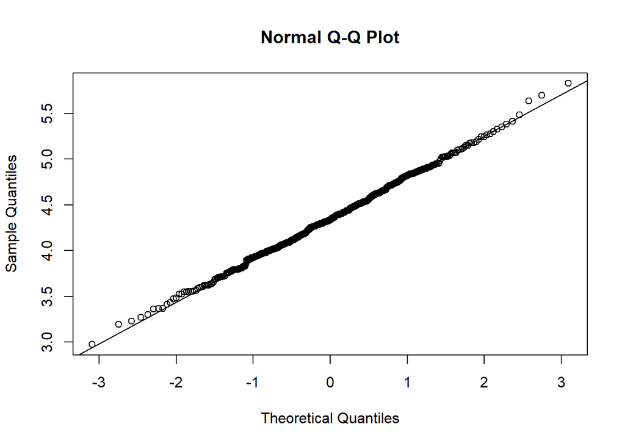

```r
qqnorm(x_bar1)
qqline(x_bar1)
```

The slope is approximately 0.45, approximating the standard deviation, and the intercept is about 4.3 apprioximating the mean.